# Chapter 6 Essay Questions

Statistical Modeling: A Fresh Approach

Daniel Kaplan

2016-07-18

## Problem 6.1

Using your general knowledge about the world, think about the relationship between these variables:

1. `speed` of a bicyclist.
2. `steepness` of the road, a quantitative variable measured by the grade (rise over run). 0 means flat, + means uphill, $-$ means downhill.
3. `fitness` of the rider, a categorical variable with three levels: unfit, average, athletic.

On a piece of paper, sketch out a graph of speed versus steepness for reasonable models of each of these forms:

MODEL 1 ANSWER: Imagine that positive steepness means uphill, and negative steepness is downhill. As the hill gets steeper uphill, bicycle speed gets slower. So this model would be a line that slopes negatively. MODEL 2 ANSWER: Increased fitness leads to higher speed, so the line of speed against fittness will slope upwards. MODEL 3 ANSWER: Speed will go down with greater steepness (uphill) and speed will go up with greater fitness. MODEL 4 ANSWER: Compared to Model 3, what’s new here is the interaction term between steepness and fitness. Presumably, more fit people don’t slow down as much when they encounter a hill, so the interaction should reduce the effect of steepness.

- Model 1: `speed` ~ 1 + `steepness`
- Model 2: `speed` ~ 1 + `fitness`
- Model 3: `speed` ~ 1 + `steepness`+`fitness`
- Model 4: `speed` ~ 1 + `steepness`+`fitness` + `steepness`:`fitness``

## Problem 6.2

1. D — a quantitative variable
2. A — a quantitative variable
3. G — a categorical variable with two levels: S & K

For each of the following, sketch a graph of the fitted model function of the indicated structure. Only a qualitative sketch is needed. (If you are doing this exercise on the internet, it will be good enough to draw out the graph on a piece of paper, roughly approximating the patterns of S and K seen in the graph. Then draw the model values right on your paper.)

An Example: `D ~ G`

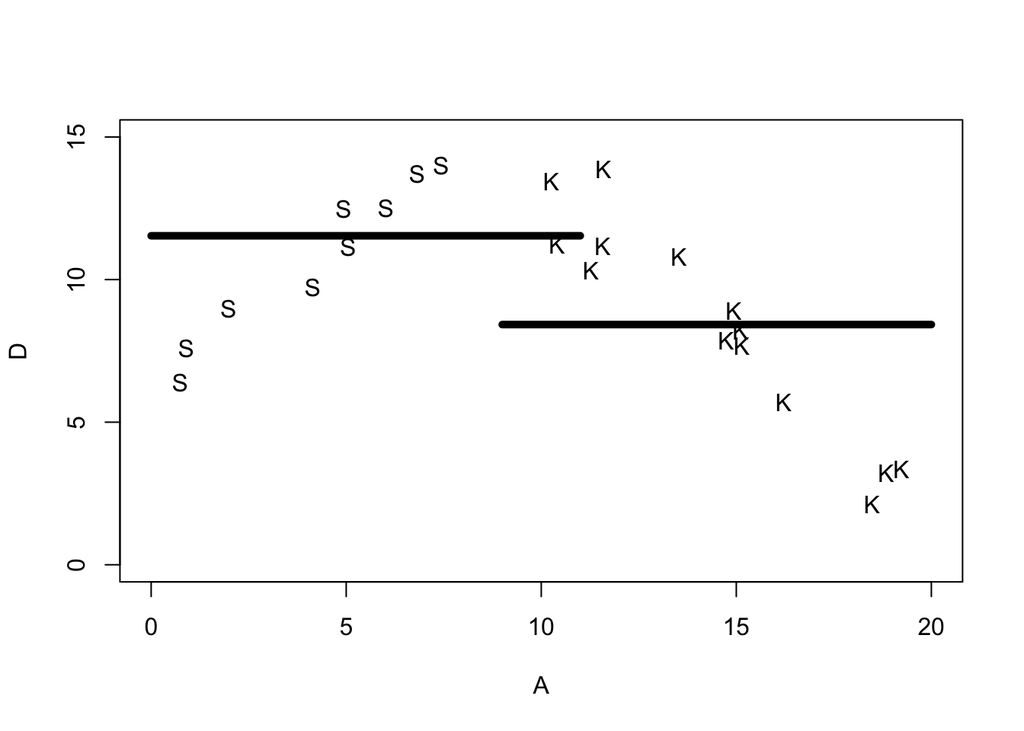

Draw these models:

1. D ~ A + G

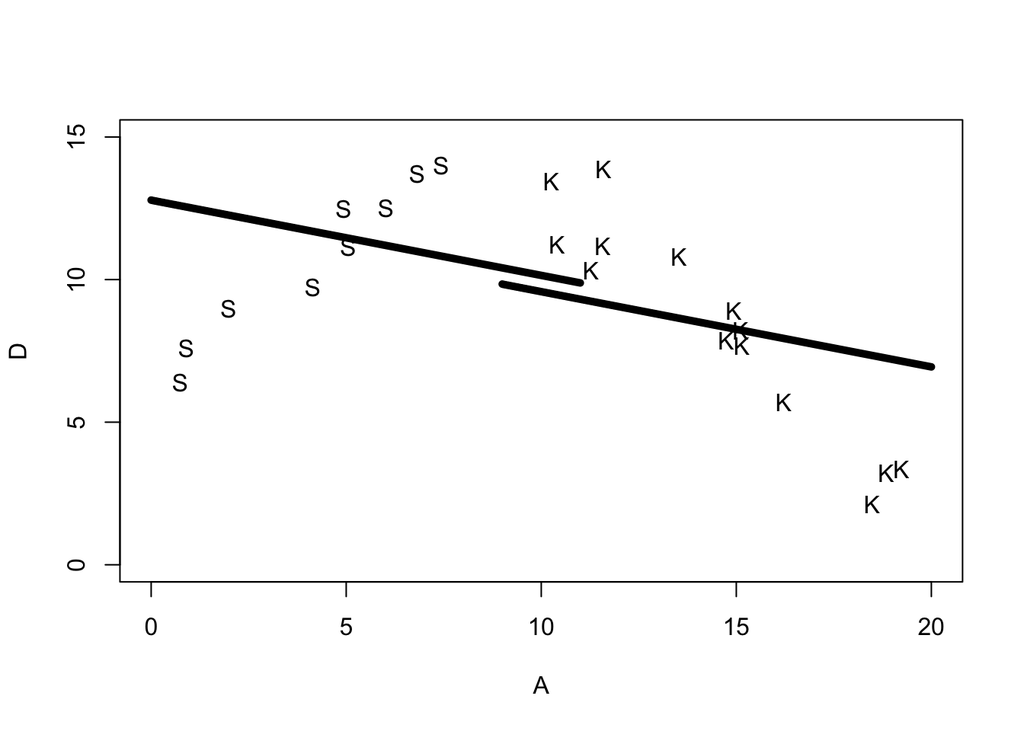

2. D ~ A * G

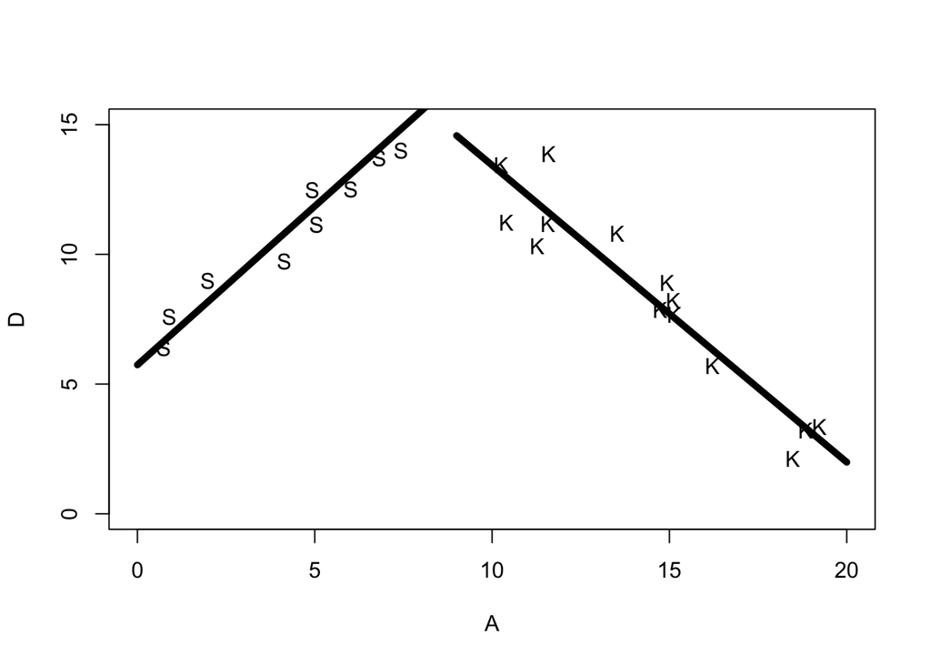

3. D ~ A - 1

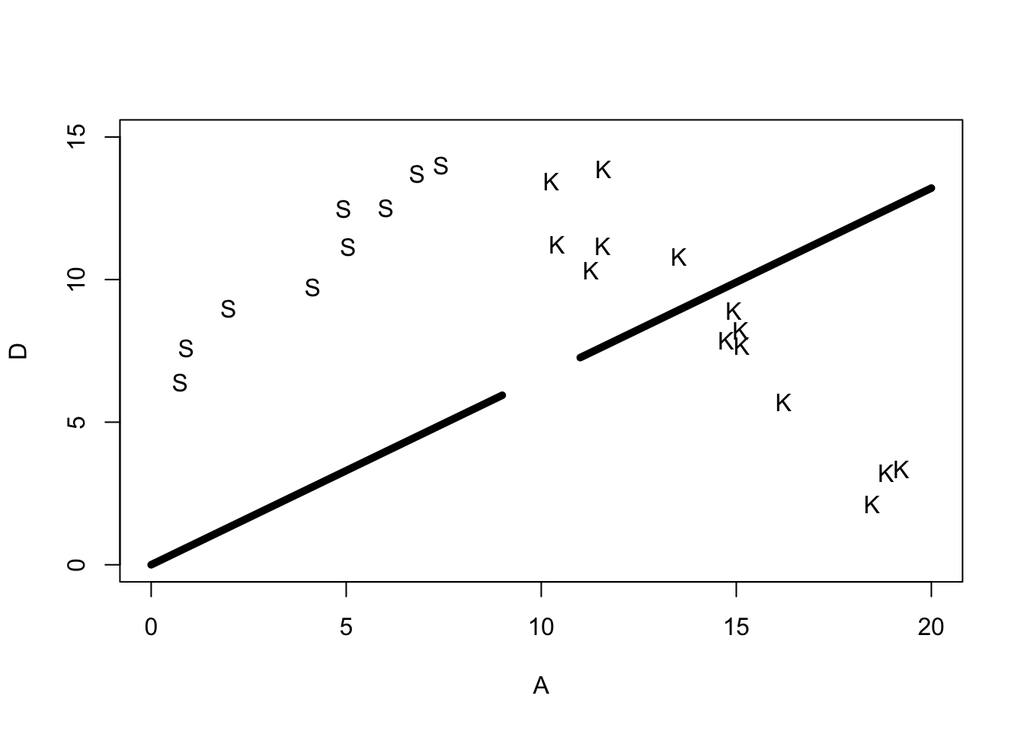

4. D ~ 1

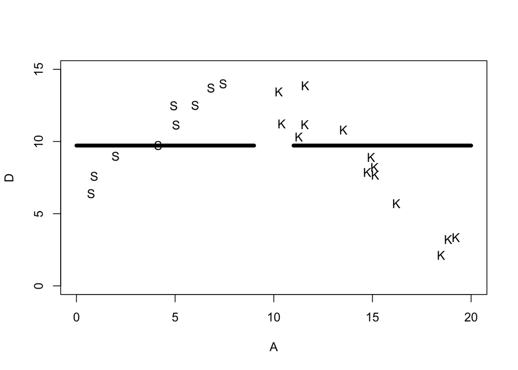

5. D ~ A

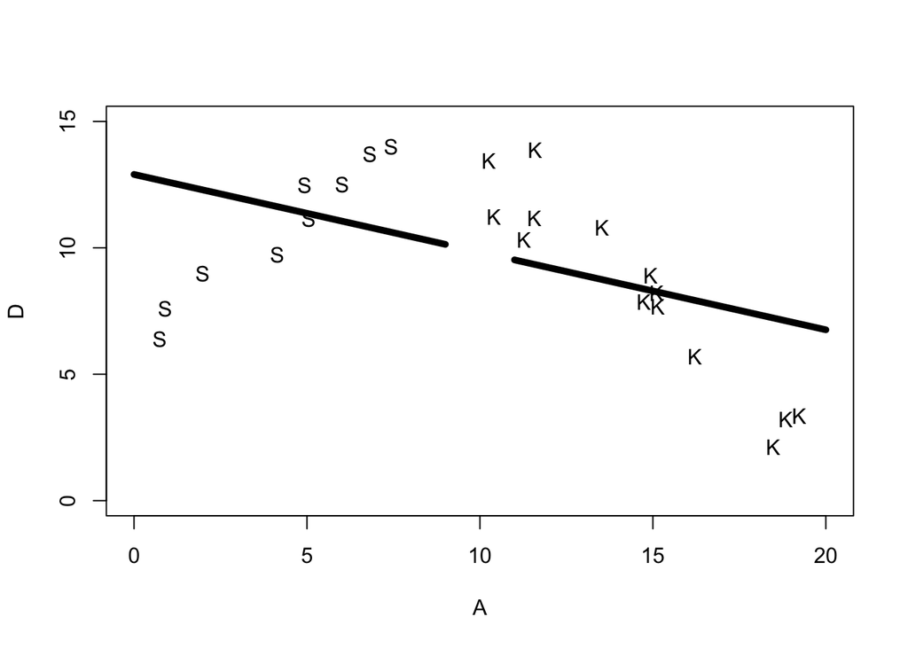

6. poly(A, 2)

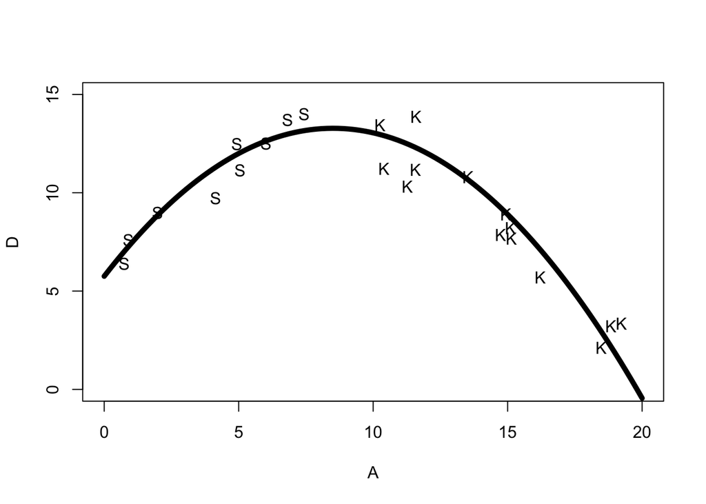